# INN_Learner_Notebook_Full_code

### Neural Network with Balanced Data (by applying SMOTE) and Adam Optimizer

#### Model 8

```python
# clears the current Keras session, resetting all layers and models previously created, freeing up memory and resources.
tf.keras.backend.clear_session()
```

```python
#Initializing the neural network
model = Sequential()
model.add(Dense(128,activation="relu",input_dim = X_train.shape[1]))
model.add(Dense(64,activation="tanh"))
model.add(Dense(1,activation ="sigmoid"))
```

```python
model.summary()
```

```
Model: "sequential"
_________________________________________________________________
 Layer (type)                Output Shape              Param #
=================================================================
 dense (Dense)               (None, 128)               1536

 dense_1 (Dense)             (None, 64)                8256

 dense_2 (Dense)             (None, 1)                 65

=================================================================
Total params: 9857 (38.50 KB)
Trainable params: 9857 (38.50 KB)
Non-trainable params: 0 (0.00 Byte)
_________________________________________________________________
```

```python
optimizer = keras.optimizers.Adam()
model.compile(loss="binary_crossentropy", optimizer=optimizer, metrics=["accuracy"])
```

```python
start = time.time()
history = model.fit(X_train_over, y_train_over, validation_data=(X_val,y_val) , batch_size=batch_size, epochs=epochs)
end=time.time()
```

```python
print("Time taken in seconds ",end-start)
```

```
Time taken in seconds  40.27714395523071
```

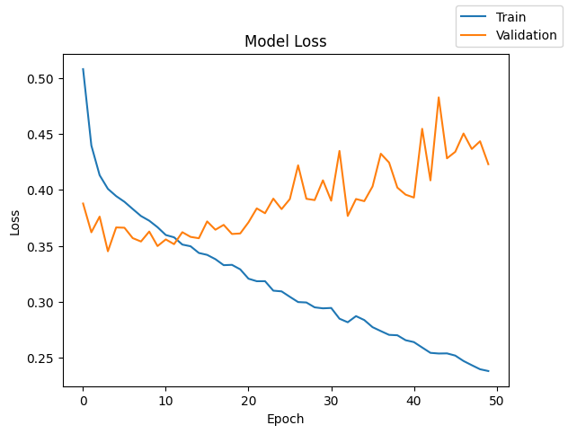

```python
plot(history,'loss')
```

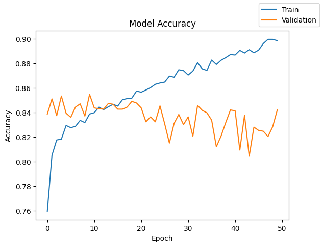

```python
plot(history,'accuracy')
```

```python
results.loc[8] = [2,[128,64],["relu","tanh"],50,32,"Adam",["SMOTE"],history.history["loss"][-1],history.history["val_loss"][-1],history.history["accuracy"][-1],history.history["val_accuracy"][-1],round(end-start,2)]
```

### Neural Network with Balanced Data (by applying SMOTE), Adam Optimizer, and Dropout

#### Model 9

- Dropout = 0.3

```python
# clears the current Keras session, resetting all layers and models previously created, freeing up memory and resources.
tf.keras.backend.clear_session()
```

```python
dropout_rate = 0.3  # defining the dropout ratio
```

```python
#Initializing the neural network
model = Sequential()
model.add(Dense(128,activation="relu",input_dim = X_train.shape[1]))
model.add(Dropout(dropout_rate))
model.add(Dense(64,activation="tanh"))
model.add(Dense(1,activation ="sigmoid"))
```

```python
model.summary()
```

```
Model: "sequential"
_________________________________________________________________
 Layer (type)                Output Shape              Param #
=================================================================
 dense (Dense)               (None, 128)               1536

 dropout (Dropout)           (None, 128)               0

 dense_1 (Dense)             (None, 64)                8256

 dense_2 (Dense)             (None, 1)                 65

=================================================================
Total params: 9857 (38.50 KB)
Trainable params: 9857 (38.50 KB)
Non-trainable params: 0 (0.00 Byte)
_________________________________________________________________
```

```python
optimizer = keras.optimizers.Adam()
model.compile(loss="binary_crossentropy", optimizer=optimizer, metrics=["accuracy"])
```

```python
start = time.time()
history = model.fit(X_train_over, y_train_over, validation_data=(X_val,y_val) , batch_size=batch_size, epochs=epochs)
end=time.time()
```

```python
print("Time taken in seconds ",end-start)
```

```
Time taken in seconds  31.582151889801025
```

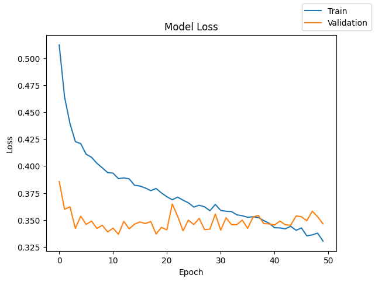

```python
plot(history,'loss')
```

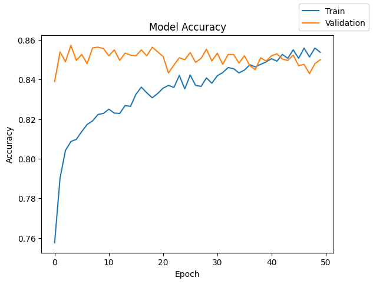

```python
plot(history,'accuracy')
```

```python
results.loc[9] = [2,[128,64],["relu","tanh"],50,32,"Adam",["SMOTE","Dropout (0.3)"],history.history["loss"][-1],history.history["val_loss"][-1],history.history["accuracy"][-1],history.history["val_accuracy"][-1],round(end-start,2)]
```

#### Model 10

- Dropout = 0.4

```python
# clears the current Keras session, resetting all layers and models previously created, freeing up memory and resources.
tf.keras.backend.clear_session()
```

```python
dropout_rate = 0.4  # defining the dropout ratio
```

```python
#Initializing the neural network
model = Sequential()
model.add(Dense(128,activation="relu",input_dim = X_train.shape[1]))
model.add(Dropout(dropout_rate))
model.add(Dense(64,activation="tanh"))
model.add(Dense(1,activation ="sigmoid"))
```

```python
model.summary()
```

```
Model: "sequential"
_________________________________________________________________
 Layer (type)                Output Shape              Param #
=================================================================
 dense (Dense)               (None, 128)               1536

 dropout (Dropout)           (None, 128)               0

 dense_1 (Dense)             (None, 64)                8256

 dense_2 (Dense)             (None, 1)                 65

=================================================================
Total params: 9857 (38.50 KB)
Trainable params: 9857 (38.50 KB)
Non-trainable params: 0 (0.00 Byte)
_________________________________________________________________
```

```python
optimizer = keras.optimizers.Adam()
model.compile(loss="binary_crossentropy", optimizer=optimizer, metrics=["accuracy"])
```

```python
start = time.time()
history = model.fit(X_train_over, y_train_over, validation_data=(X_val,y_val) , batch_size=batch_size, epochs=epochs)
end=time.time()
```

```python
print("Time taken in seconds ",end-start)
```

```
Time taken in seconds  32.29324507713318
```

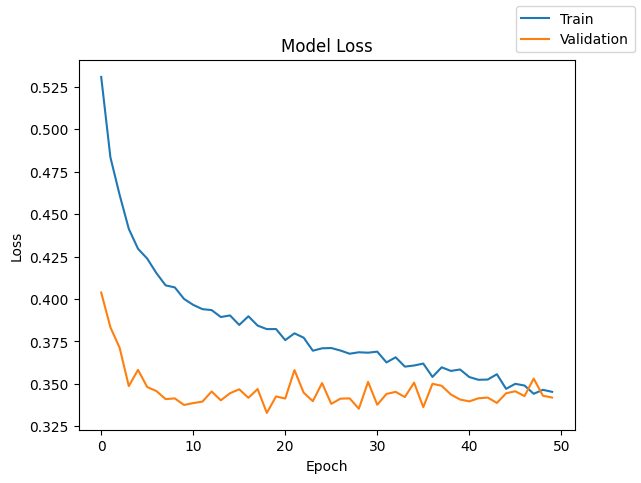

```python
plot(history,'loss')
```

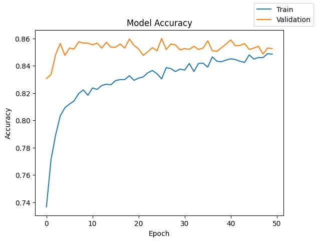

```python
plot(history,'accuracy')
```

```python
results.loc[10] = [2,[128,64],["relu","tanh"],50,32,"Adam",["SMOTE","Dropout (0.4)"],history.history["loss"][-1],history.history["val_loss"][-1],history.history["accuracy"][-1],history.history["val_accuracy"][-1],round(end-start,2)]
```

#### Model 11

- Dropout = 0.5

```python
# clears the current Keras session, resetting all layers and models previously created, freeing up memory and resources.
tf.keras.backend.clear_session()
```

```python
dropout_rate = 0.5  # defining the dropout ratio
```

```python
#Initializing the neural network
model = Sequential()
model.add(Dense(128,activation="relu",input_dim = X_train.shape[1]))
model.add(Dropout(dropout_rate))
model.add(Dense(64,activation="tanh"))
model.add(Dense(1,activation ="sigmoid"))
```

```python
model.summary()
```

```
Model: "sequential"
_________________________________________________________________
 Layer (type)                Output Shape              Param #
=================================================================
 dense (Dense)               (None, 128)               1536

 dropout (Dropout)           (None, 128)               0

 dense_1 (Dense)             (None, 64)                8256

 dense_2 (Dense)             (None, 1)                 65

=================================================================
Total params: 9857 (38.50 KB)
Trainable params: 9857 (38.50 KB)
Non-trainable params: 0 (0.00 Byte)
_________________________________________________________________
```

```python
optimizer = keras.optimizers.Adam()
model.compile(loss="binary_crossentropy", optimizer=optimizer, metrics=["accuracy"])
```

```python
start = time.time()
history = model.fit(X_train_over, y_train_over, validation_data=(X_val,y_val) , batch_size=batch_size, epochs=epochs)
end=time.time()
```

```python
print("Time taken in seconds ",end-start)
```

```
Time taken in seconds  31.622455596923828
```

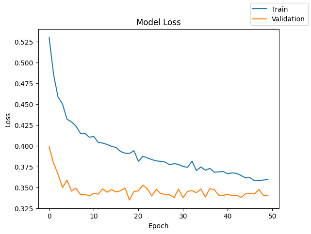

```python
plot(history,'loss')
```

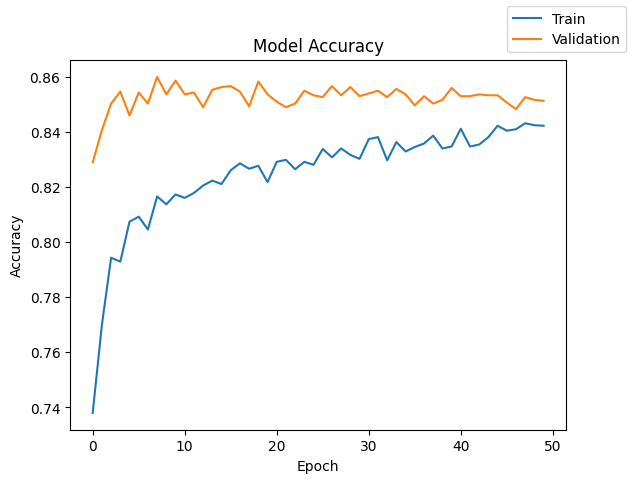

```python
plot(history,'accuracy')
```

```python
results.loc[11] = [2,[128,64],["relu","tanh"],50,32,"Adam",["SMOTE","Dropout (0.5)"],history.history["loss"][-1],history.history["val_loss"][-1],history.history["accuracy"][-1],history.history["val_accuracy"][-1],round(end-start,2)]
```

#### Model 12

- Dropout = 0.5
- Learning Rate = 0.0001

```python
# clears the current Keras session, resetting all layers and models previously created, freeing up memory and resources.
tf.keras.backend.clear_session()
```

```python
dropout_rate = 0.5  # defining the dropout ratio
```

```python
#Initializing the neural network
model = Sequential()
model.add(Dense(128,activation="relu",input_dim = X_train.shape[1]))
model.add(Dropout(dropout_rate))
model.add(Dense(64,activation="tanh"))
model.add(Dense(1,activation ="sigmoid"))
```

```python
model.summary()
```

```
Model: "sequential"
_________________________________________________________________
 Layer (type)                Output Shape              Param #
=================================================================
 dense (Dense)               (None, 128)               1536

 dropout (Dropout)           (None, 128)               0

 dense_1 (Dense)             (None, 64)                8256

 dense_2 (Dense)             (None, 1)                 65

=================================================================
Total params: 9857 (38.50 KB)
Trainable params: 9857 (38.50 KB)
Non-trainable params: 0 (0.00 Byte)
_________________________________________________________________
```

```python
lr = 1e-4    # defining the learning rate; 1e-4 is equal to 0.0001
optimizer = keras.optimizers.Adam(learning_rate=lr)
model.compile(loss="binary_crossentropy", optimizer=optimizer, metrics=["accuracy"])
```

```python
start = time.time()
history = model.fit(X_train_over, y_train_over, validation_data=(X_val,y_val) , batch_size=batch_size, epochs=epochs)
end=time.time()
```

```python
print("Time taken in seconds ",end-start)
```

```
Time taken in seconds  32.12631058692932
```

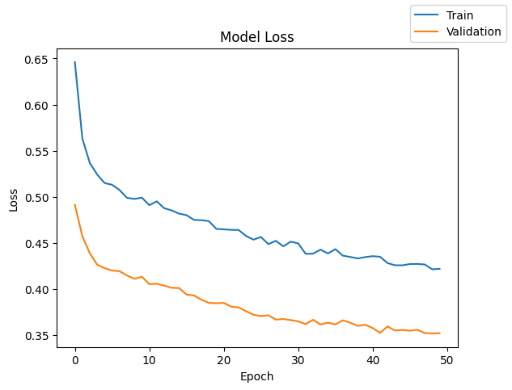

```python
plot(history,'loss')
```

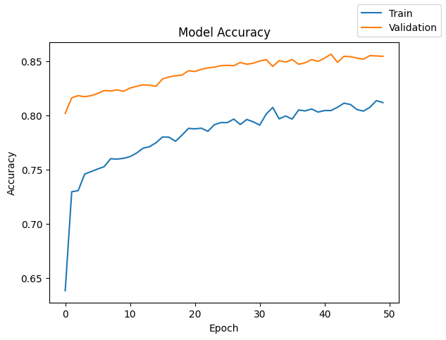

```python
plot(history,'accuracy')
```

```python
results.loc[12] = [2,[128,64],["relu","tanh"],50,32,"Adam",["SMOTE","Dropout (0.5)","LearnRate (.0001)"],history.history["loss"][-1],history.history["val_loss"][-1],history.history["accuracy"][-1],history.history["val_accuracy"][-1],round(end-start,2)]
```

### Observations on different Neural Networks

- Based on the Loss & Accuracy plots for different models we developed, we can see the following trends:
  - When using Stochastic Gradient Descent (SGD) optimizer, the loss plot was pretty smooth, but the accuracy plot had shorter jagged lines.
  - In case of Adam optimizer, we could see that both loss plots & accuracy plots had pretty tall & sharp jagged lines.
    - We were able to make it smoother by slowing the learning rate to 0.0001
    - We were also able to improve performance of these neural networks by introducing Dropouts.
  - We could see that SGD optimized models took lesser time than the Adam optimized models in general.
    - It got even worse when using the synthesized data using SMOTE in the train set.
    - And even though we ended up increasing the time taken, we were not really seeing any significant improvements either.

## Model Performance Comparison and Final Model Selection

#### Let's compare performances of different models

- We have been collecting the passed parameters and the metrics information for each model in the **results** dataframe. Let's take a look at it:

```python
results
```

|  | #hidden layers | #neurons - hidden layer | activation function - hidden layer | #epochs | batch size | optimizer | regularization | train loss | validation loss | train accuracy | validation accuracy | time (secs) |
| --- | --- | --- | --- | --- | --- | --- | --- | --- | --- | --- | --- | --- |
| 0 | 2 | [128, 64] | [relu, tanh] | 50 | 32 | SGD | [-] | 0.329703 | 0.339727 | 0.866400 | 0.858000 | 25.75 |
| 1 | 2 | [128, 64] | [relu, tanh] | 50 | 32 | SGD | [LearnRate (.0001)] | 0.373464 | 0.343939 | 0.845800 | 0.859667 | 28.55 |
| 2 | 2 | [128, 64] | [relu, tanh] | 50 | 32 | Adam | [-] | 0.259021 | 0.385333 | 0.893200 | 0.838667 | 27.46 |
| 3 | 2 | [128, 64] | [relu, tanh] | 50 | 32 | Adam | [Dropout (0.3)] | 0.309006 | 0.335256 | 0.871600 | 0.858000 | 30.31 |
| 4 | 2 | [128, 64] | [relu, tanh] | 50 | 32 | Adam | [Dropout (0.4)] | 0.311599 | 0.332854 | 0.873400 | 0.861000 | 29.92 |
| 5 | 2 | [128, 64] | [relu, tanh] | 50 | 32 | Adam | [Dropout (0.5)] | 0.328532 | 0.330043 | 0.864600 | 0.858667 | 29.97 |
| 6 | 2 | [128, 64] | [relu, tanh] | 50 | 32 | Adam | [Dropout (0.5), LearnRate (.0001)] | 0.371815 | 0.346158 | 0.844400 | 0.860000 | 38.29 |
| 7 | 2 | [128, 64] | [relu, tanh] | 50 | 32 | SGD | [SMOTE] | 0.368845 | 0.365805 | 0.836354 | 0.837667 | 40.83 |
| 8 | 2 | [128, 64] | [relu, tanh] | 50 | 32 | Adam | [SMOTE] | 0.238319 | 0.423038 | 0.898439 | 0.842333 | 40.28 |
| 9 | 2 | [128, 64] | [relu, tanh] | 50 | 32 | Adam | [SMOTE, Dropout (0.3)] | 0.330343 | 0.346291 | 0.853759 | 0.850000 | 31.58 |
| 10 | 2 | [128, 64] | [relu, tanh] | 50 | 32 | Adam | [SMOTE, Dropout (0.4)] | 0.345318 | 0.341962 | 0.848556 | 0.852667 | 32.29 |
| 11 | 2 | [128, 64] | [relu, tanh] | 50 | 32 | Adam | [SMOTE, Dropout (0.5)] | 0.359572 | 0.339928 | 0.842275 | 0.851333 | 31.62 |
| 12 | 2 | [128, 64] | [relu, tanh] | 50 | 32 | Adam | [SMOTE, Dropout (0.5), LearnRate (.0001)] | 0.421858 | 0.352041 | 0.811951 | 0.854667 | 32.13 |

#### Best Model

- Based on the train & validation accuracy scores and the amount of time taken (& complexity), we can see that **Neural Network with SGD Optimizer** having **Learning Rate** of ***0.0001*** seems to be giving the best performance.
  - This is the model with one among the least complexity & takes among the least time.
  - Also, this model seems to be one among the least overfitting.
- Now, we can evaluate the performance of this model against the unseen dataset (test) as well.
- **Disclaimer**: I tried to evaluate the performance of all different models on the test dataset (*after clearing the cache each time*) and **SGD with lowered Learning Rate** seemed to perform best out of all.

#### Let's now evaluate the performance of the selected model on unseen test data.

```python
# clears the current Keras session, resetting all layers and models previously created, freeing up memory and resources.
tf.keras.backend.clear_session()
```

```python
#Initializing the neural network
model = Sequential()
model.add(Dense(128,activation="relu",input_dim = X_train.shape[1]))
model.add(Dense(64,activation="tanh"))
model.add(Dense(1,activation ="sigmoid"))
```

```python
lr = 1e-4    # defining the learning rate; 1e-4 is equal to 0.0001
optimizer = keras.optimizers.SGD (learning_rate=lr)
model.compile(loss="binary_crossentropy", optimizer=optimizer, metrics=["accuracy"])
```

```python
model.fit(X_train, y_train, validation_data=(X_val,y_val) , batch_size=batch_size, epochs=epochs)
```

```
<keras.src.callbacks.History at 0x1f4c83ff010>
```

```python
test_loss, test_accuracy = model.evaluate(X_test, y_test)
print(f'Test Loss: {test_loss}')
print(f'Test Accuracy: {test_accuracy}')
```

```
Test Loss: 0.559359073638916
Test Accuracy: 0.796500027179718
```

## Actionable Insights and Business Recommendations

- We have identified the model which gives the best performance among everything else on the test dataset.
  - Which means that this neural network can make predictions with ~79% accuracy about a user attriting the bank.

#### Setting the Evaluation Requirements / Priorities

- Based on the model performance, if the model predicts a hundred users would attrite, then there is a high probability that 80 of those users are actually planning to attrite and others might be on the fence.
  - So, it is safe to classify all those customers as attriting customers.
  - Even if there are any False Positives, the user wouldn't have attrited but would end up getting the benefits an attriting customer would have gotten, which wouldn't do any harm.
  - But, not targeting an actually attriting customer would result in revenue loss.
  - So, our model needs to be more tolerant towards False Positives.

#### Areas of Interest

- Also, based on the the EDA, there are areas of interest that we can highlight for the Bank, for them to work on to reduce attrition:
  - There seem to be around 50% of users being inactive, which isn't a good sign. An engaged user means a lasting user and an inactive user means an attriting user.
    - So, upon signs of prolonged inactivity, users should be prompted to stay active by introducing schemes like quarterly cashback offers, which changes each quarter and users need to sign-in and activate such offers each quarter or loose the benefits.
      - This will keep them active and reduce their chances of attrition.
  - Elder customers are having some significant reasons to leave the Bank. Maybe they don't see any value or benefits that they anticipate to receive. Good area to research.
    - New programs / schemes should be introduced by the Bank to engage and reward the senior customer base of the bank, for them to feel valued for their legacy & tenure.

Power Ahead ___